# Module 113

#### Contrast SVE:

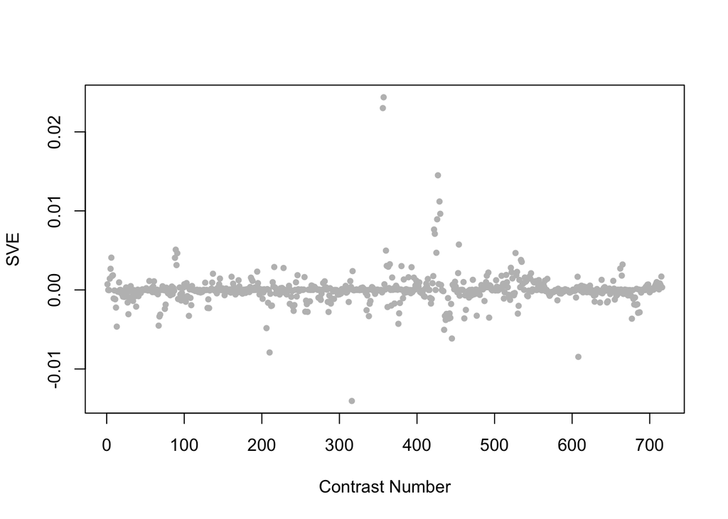

Positive SVE Contrasts:

|  | Contrast.Num | SVE | GEO.GSE | Cond.1 | Cond.2 | Mutation |
| --- | --- | --- | --- | --- | --- | --- |
| GSE38196.s1t2.vs.s0t2 | 357 | 0.02 | GSE38196 | atfs-1(tm4525)-treated, biological rep1 | wild-type-treated, biological rep1 | afts-1 |
| GSE38196.s1t1.vs.s0t1 | 356 | 0.02 | GSE38196 | atfs-1(tm4525)-control, biological rep1 | wild-type-control, biological rep1 | afts-1 |
| GSE27677A.s1t2.vs.s0t2 | 427 | 0.01 | GSE27677 | kgb-1, Fast , rep 1 | N2, Fast , rep 1 | kgb-1 |
| GSE27677A.s2t1.vs.s0t1 | 429 | 0.01 | GSE27677 | jun-1, Fed , rep 1 | N2, Fed , rep 1 | 40694 |
| GSE27677A.s1t1.vs.s0t1 | 430 | 0.01 | GSE27677 | kgb-1, Fed , rep 1 | N2, Fed , rep 1 | kgb-1 |

Negative SVE Contrasts:

|  | Contrast.Num | SVE | GEO.GSE | Cond.1 | Cond.2 | Mutation |
| --- | --- | --- | --- | --- | --- | --- |
| GSE39252.s1t1.vs.s0t1 | 316 | -0.01 | GSE39252 | xpa-1_rep1 | N2_rep1 | xpa-1 |
| GSE21747.s1t1.vs.s0t1 | 608 | -0.01 | GSE21747 | albendazole exposure, biological rep 1 | no albendazole exposure, biological rep 1 |  |
| GSE42689.s3t1.vs.s1t1 | 210 | -0.01 | GSE42689 | mlk-1 fasted 1 | mek-1 fasted 1 |  |
| GSE27677B.s0t9.vs.s0t7 | 445 | -0.01 | GSE27677 | N2, Fed 48 h, rep 1 | N2, Fed 24 h, rep 1 |  |
| GSE27677B.s1t7.vs.s0t7 | 435 | -0.01 | GSE27677 | N2, Fast 24 h, rep 1 | N2, Fed 24 h, rep 1 |  |

$~$

#### Contrast SVE, Up-Regulated Genes Only:

Calculating SVE for up-regulated and down-regulated genes separately may be more informative in many cases than projecting the up- and down- gene sets together. This is due to the fact that the weight distribution of many modules is highly skewed, indicating that only one of the hemi-modules may be biologically meaningful (i.e., a set of genes are strongly correlated by only a few genes (or none) are strongly anti-correlated to that set.)

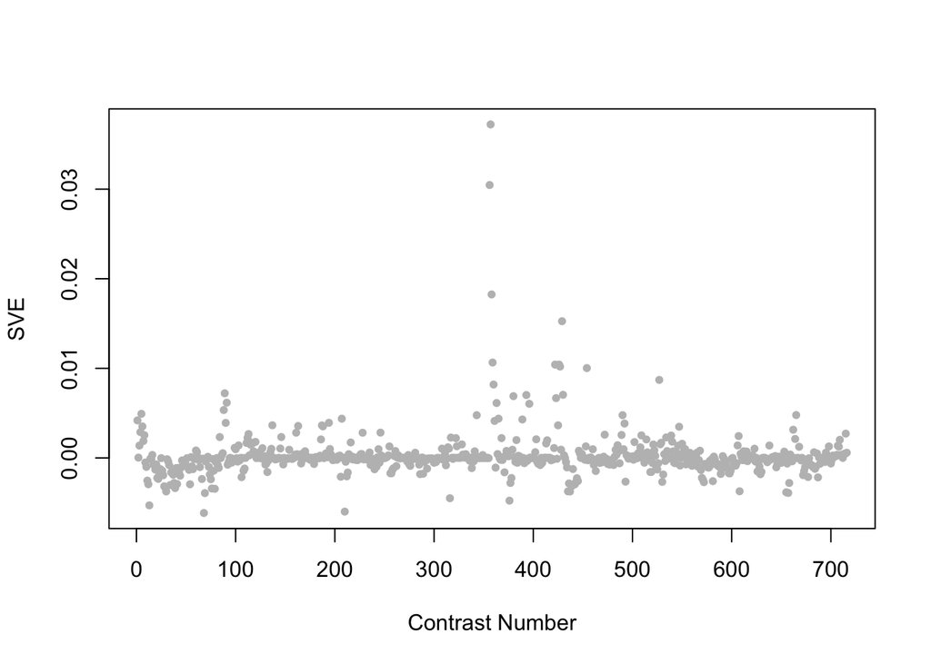

Positive SVE Contrasts:

|  | Contrast.Num | SVE | GEO.GSE | Cond.1 | Cond.2 | Mutation |
| --- | --- | --- | --- | --- | --- | --- |
| GSE38196.s1t2.vs.s0t2 | 357 | 0.04 | GSE38196 | atfs-1(tm4525)-treated, biological rep1 | wild-type-treated, biological rep1 | afts-1 |
| GSE38196.s1t1.vs.s0t1 | 356 | 0.03 | GSE38196 | atfs-1(tm4525)-control, biological rep1 | wild-type-control, biological rep1 | afts-1 |
| GSE38196.s1t2.vs.s1t1 | 358 | 0.02 | GSE38196 | atfs-1(tm4525)-treated, biological rep1 | atfs-1(tm4525)-control, biological rep1 | spg-7(RNAi) |
| GSE27677A.s2t1.vs.s0t1 | 429 | 0.02 | GSE27677 | jun-1, Fed , rep 1 | N2, Fed , rep 1 | 40694 |
| GSE38196.s0t2.vs.s0t1 | 359 | 0.01 | GSE38196 | wild-type-treated, biological rep1 | wild-type-control, biological rep1 | spg-7(RNAi) |

Negative SVE Contrasts:

|  | Contrast.Num | SVE | GEO.GSE | Cond.1 | Cond.2 | Mutation |
| --- | --- | --- | --- | --- | --- | --- |
| GSE8462.s2t1.vs.s1t1 | 68 | -0.01 | GSE8462 | 0 hr Reference, biological rep 1 | 0 hr muscle, biological rep 1 |  |
| GSE42689.s3t1.vs.s1t1 | 210 | -0.01 | GSE42689 | mlk-1 fasted 1 | mek-1 fasted 1 |  |
| GSE9682.s2t2.vs.s0t2 | 13 | -0.01 | GSE9682 | N2-Cel-TORRNAi-fed-biological rep1 | N2-controlRNAi-fed-biological rep1 | TOR |
| GSE35354B.s1t2.vs.s1t1 | 376 | -0.00 | GSE35354 | TA100_rep1 | TA Control_rep1 |  |
| GSE39252.s1t1.vs.s0t1 | 316 | -0.00 | GSE39252 | xpa-1_rep1 | N2_rep1 | xpa-1 |

$~$

#### Contrast SVE, Down-Regulated Genes Only:

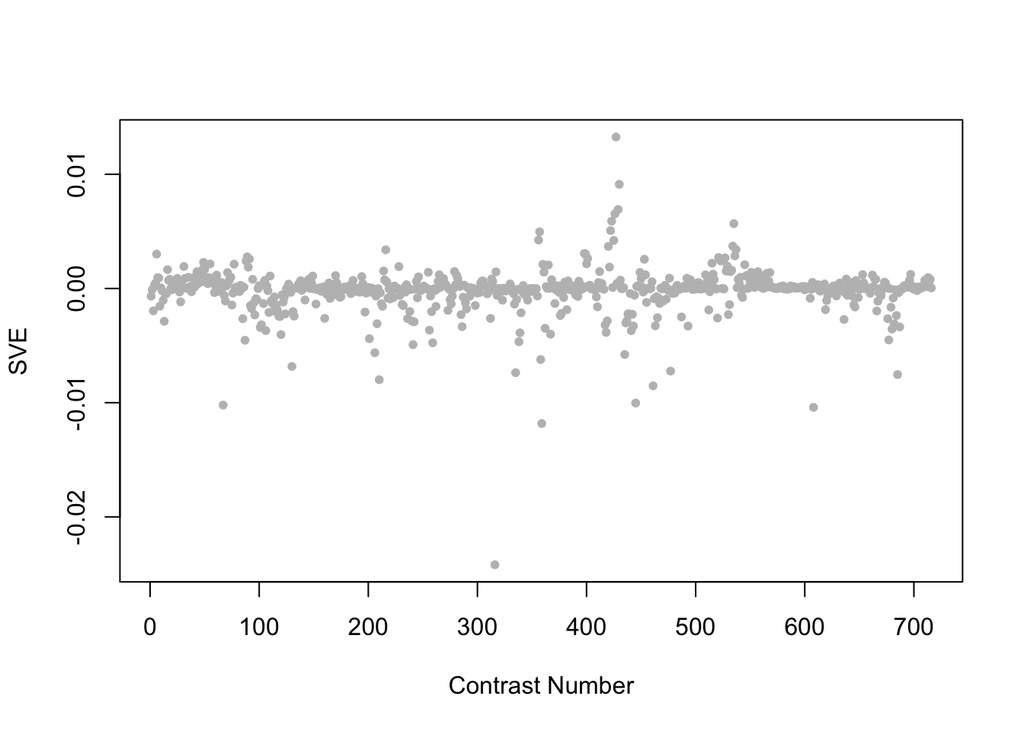

Positive SVE Contrasts:

|  | Contrast.Num | SVE | GEO.GSE | Cond.1 | Cond.2 | Mutation |
| --- | --- | --- | --- | --- | --- | --- |
| GSE27677A.s1t2.vs.s0t2 | 427 | 0.01 | GSE27677 | kgb-1, Fast , rep 1 | N2, Fast , rep 1 | kgb-1 |
| GSE27677A.s1t1.vs.s0t1 | 430 | 0.01 | GSE27677 | kgb-1, Fed , rep 1 | N2, Fed , rep 1 | kgb-1 |
| GSE27677A.s2t1.vs.s0t1 | 429 | 0.01 | GSE27677 | jun-1, Fed , rep 1 | N2, Fed , rep 1 | 40694 |
| GSE27677A.s2t2.vs.s0t2 | 426 | 0.01 | GSE27677 | jun-1, Fast , rep 1 | N2, Fast , rep 1 | 40694 |
| GSE28494.s0t2.vs.s0t1 | 423 | 0.01 | GSE28494 | wild-type N2 dissected germline 1 | wild-type N2 embryo 1 |  |

Negative SVE Contrasts:

|  | Contrast.Num | SVE | GEO.GSE | Cond.1 | Cond.2 | Mutation |
| --- | --- | --- | --- | --- | --- | --- |
| GSE39252.s1t1.vs.s0t1 | 316 | -0.02 | GSE39252 | xpa-1_rep1 | N2_rep1 | xpa-1 |
| GSE38196.s0t2.vs.s0t1 | 359 | -0.01 | GSE38196 | wild-type-treated, biological rep1 | wild-type-control, biological rep1 | spg-7(RNAi) |
| GSE21747.s1t1.vs.s0t1 | 608 | -0.01 | GSE21747 | albendazole exposure, biological rep 1 | no albendazole exposure, biological rep 1 |  |
| GSE8659.s3t1.vs.s2t1 | 67 | -0.01 | GSE8659 | strain NL 2099 replicate 2 | strain GR1373 replicate 1 |  |
| GSE27677B.s0t9.vs.s0t7 | 445 | -0.01 | GSE27677 | N2, Fed 48 h, rep 1 | N2, Fed 24 h, rep 1 |  |

$~$

$~$

#### GO Term Enrichment:

This analysis tests each hemi-module for enrichment of specific GO terms. Only gene-level annotations (e.g., as would be found on the gene’s page in Wormbase) are tested - the hierarchical structure of the GO ontology is not taken into account.

*Note: At least the top two most enriched terms from each GO domain (BP/MF/CC) are shown, even when not statistically significant.*

##### Enriched GO terms: Hemi-module A

| ID | GO.Term | GO Domain | Raw p-value | Adj p-value |
| --- | --- | --- | --- | --- |
| [GO_0007548](http://amigo.geneontology.org/amigo/term/GO:0007548) | sex differentiation | BP | 4.99e-03 | 9.98e-01 |
| [GO_0006837](http://amigo.geneontology.org/amigo/term/GO:0006837) | serotonin transport | BP | 5.07e-03 | 9.98e-01 |
| [GO_0016705](http://amigo.geneontology.org/amigo/term/GO:0016705) | oxidoreductase activity, acting on paired donors, with incorporation or reduction of molecular oxygen | MF | 7.09e-04 | 1.00e+00 |
| [GO_0004497](http://amigo.geneontology.org/amigo/term/GO:0004497) | monooxygenase activity | MF | 1.06e-03 | 1.00e+00 |
| [GO_0005883](http://amigo.geneontology.org/amigo/term/GO:0005883) | neurofilament | CC | 5.07e-03 | 9.99e-01 |
| [GO_0071683](http://amigo.geneontology.org/amigo/term/GO:0071683) | sensory dendrite | CC | 1.01e-02 | 9.99e-01 |

##### Enriched GO terms: Hemi-module B

| ID | GO.Term | GO Domain | Raw p-value | Adj p-value |
| --- | --- | --- | --- | --- |
| [GO_0007157](http://amigo.geneontology.org/amigo/term/GO:0007157) | heterophilic cell-cell adhesion via plasma membrane cell adhesion molecules | BP | 2.66e-03 | 1.00e+00 |
| [GO_0034769](http://amigo.geneontology.org/amigo/term/GO:0034769) | basement membrane disassembly | BP | 5.31e-03 | 1.00e+00 |
| [GO_0004494](http://amigo.geneontology.org/amigo/term/GO:0004494) | methylmalonyl-CoA mutase activity | MF | 1.33e-03 | 1.00e+00 |
| [GO_0016866](http://amigo.geneontology.org/amigo/term/GO:0016866) | intramolecular transferase activity | MF | 2.66e-03 | 1.00e+00 |
| [GO_0016020](http://amigo.geneontology.org/amigo/term/GO:0016020) | membrane | CC | 1.10e-02 | 1.00e+00 |
| [GO_0016021](http://amigo.geneontology.org/amigo/term/GO:0016021) | integral component of membrane | CC | 1.83e-02 | 1.00e+00 |

$~$

$~$

#### Tissue Enrichment:

This analysis tests each hemi-module for enrichment of genes associated with anatomy terms. Negative enrichment scores indicate fewer hemi-module genes than expected by random chance were associated with the anatomy term in question.

##### Enriched tissues: Hemi-module A

| ID | Anatomy.Term | Definition | Raw p-value | Adj p-value |
| --- | --- | --- | --- | --- |
| [WBbt_0004027](https://wormbase.org/species/all/anatomy_term/WBbt:0004027) | R4BR | Post-embryonic cell of pedigree V6R.pppapapa, male sensory rays, neuron, darkly staining tip, open to outside. | 3.64e-06 | 2.67e-03 |
| [WBbt_0004028](https://wormbase.org/species/all/anatomy_term/WBbt:0004028) | R4BL | Post-embryonic cell of pedigree V6L.pppapapa, male sensory rays, neuron, darkly staining tip, open to outside. | 3.64e-06 | 2.67e-03 |
| [WBbt_0003988](https://wormbase.org/species/all/anatomy_term/WBbt:0003988) | R8BR | Male sensory rays, neuron, darkly staining tip, open to outside | 4.39e-06 | 2.67e-03 |
| [WBbt_0003990](https://wormbase.org/species/all/anatomy_term/WBbt:0003990) | R8BL | Post-embryonic cell of pedigree TL.appaaapa, male sensory rays, neuron, darkly staining tip, open to outside. | 4.39e-06 | 2.67e-03 |
| [WBbt_0004052](https://wormbase.org/species/all/anatomy_term/WBbt:0004052) | R1AL | Post-embryonic cell of pedigree V5L.pppppaaa, male sensory rays, neuron, striated rootlet. | 5.86e-05 | 6.79e-03 |
| [WBbt_0004035](https://wormbase.org/species/all/anatomy_term/WBbt:0004035) | R3AR | Post-embryonic cell of pedigree V6R.papppaaa, male sensory rays, neuron, striated rootlet. | 6.37e-05 | 6.79e-03 |
| [WBbt_0004036](https://wormbase.org/species/all/anatomy_term/WBbt:0004036) | R3AL | Post-embryonic cell of pedigree V6L.papppaaa, male sensory rays, neuron, striated rootlet. | 6.37e-05 | 6.79e-03 |
| [WBbt_0003992](https://wormbase.org/species/all/anatomy_term/WBbt:0003992) | R8AR | Male sensory rays, neuron, striated rootlet | 7.49e-05 | 6.79e-03 |
| [WBbt_0003994](https://wormbase.org/species/all/anatomy_term/WBbt:0003994) | R8AL | Post-embryonic cell of pedigree TL.appaaaaa, male sensory rays, neuron, striated rootlet. | 7.49e-05 | 6.79e-03 |
| [WBbt_0004029](https://wormbase.org/species/all/anatomy_term/WBbt:0004029) | R4AR | Post-embryonic cell of pedigree V6R.pppapaaa, male sensory rays, neuron, striated rootlet. | 7.49e-05 | 6.79e-03 |
| [WBbt_0004030](https://wormbase.org/species/all/anatomy_term/WBbt:0004030) | R4AL | Post-embryonic cell of pedigree V6L.pppapaaa, male sensory rays, neuron, striated rootlet. | 7.49e-05 | 6.79e-03 |
| [WBbt_0004050](https://wormbase.org/species/all/anatomy_term/WBbt:0004050) | R1AR | Post-embryonic cell of pedigree V5R.pppppaaa, male sensory rays, neuron, striated rootlet. | 7.49e-05 | 6.79e-03 |
| [WBbt_0004002](https://wormbase.org/species/all/anatomy_term/WBbt:0004002) | R7AR | Male sensory rays, neuron, striated rootlet | 8.10e-05 | 6.79e-03 |
| [WBbt_0004006](https://wormbase.org/species/all/anatomy_term/WBbt:0004006) | R7AL | Post-embryonic cell of pedigree TL.apappaaa, male sensory rays, neuron, striated rootlet. | 8.10e-05 | 6.79e-03 |
| [WBbt_0004041](https://wormbase.org/species/all/anatomy_term/WBbt:0004041) | R2AR | Post-embryonic cell of pedigree V6R.papapaaa, male sensory rays, neuron, striated rootlet. | 8.10e-05 | 6.79e-03 |
| [WBbt_0004042](https://wormbase.org/species/all/anatomy_term/WBbt:0004042) | R2AL | Post-embryonic cell of pedigree V6L.papapaaa, male sensory rays, neuron, striated rootlet. | 8.10e-05 | 6.79e-03 |
| [WBbt_0004016](https://wormbase.org/species/all/anatomy_term/WBbt:0004016) | R6AR | Post-embryonic cell of pedigree V6R.pppppaaa, male sensory rays, neuron, striated rootlet. | 8.75e-05 | 6.79e-03 |
| [WBbt_0004018](https://wormbase.org/species/all/anatomy_term/WBbt:0004018) | R6AL | Post-embryonic cell of pedigree V6L.pppppaaa, male sensory rays, neuron, striated rootlet. | 8.75e-05 | 6.79e-03 |
| [WBbt_0004023](https://wormbase.org/species/all/anatomy_term/WBbt:0004023) | R5AR | Post-embryonic cell of pedigree V6R.ppppaaaa, male sensory rays, neuron, striated rootlet. | 8.75e-05 | 6.79e-03 |
| [WBbt_0004024](https://wormbase.org/species/all/anatomy_term/WBbt:0004024) | R5AL | Post-embryonic cell of pedigree V6L.ppppaaaa, male sensory rays, neuron, striated rootlet. | 8.75e-05 | 6.79e-03 |
| [WBbt_0004033](https://wormbase.org/species/all/anatomy_term/WBbt:0004033) | R3BR | Post-embryonic cell of pedigree V6R.papppapa, male sensory rays, neuron, darkly staining tip, open to outside. | 8.75e-05 | 6.79e-03 |
| [WBbt_0004034](https://wormbase.org/species/all/anatomy_term/WBbt:0004034) | R3BL | Post-embryonic cell of pedigree V6L.papppapa, male sensory rays, neuron, darkly staining tip, open to outside. | 8.75e-05 | 6.79e-03 |
| [WBbt_0003970](https://wormbase.org/species/all/anatomy_term/WBbt:0003970) | R9AR | Male sensory rays, neuron, striated rootlet | 9.44e-05 | 6.79e-03 |
| [WBbt_0003971](https://wormbase.org/species/all/anatomy_term/WBbt:0003971) | R9AL | Male sensory rays, neuron, striated rootlet | 9.44e-05 | 6.79e-03 |
| [WBbt_0004012](https://wormbase.org/species/all/anatomy_term/WBbt:0004012) | R6BR | Post-embryonic cell of pedigree V6R.pppppapa, male sensory rays, neuron, not darkly staining nor open to outside. | 9.44e-05 | 6.79e-03 |
| [WBbt_0004014](https://wormbase.org/species/all/anatomy_term/WBbt:0004014) | R6BL | Post-embryonic cell of pedigree V6L.pppppapa, male sensory rays, neuron, not darkly staining nor open to outside. | 9.44e-05 | 6.79e-03 |
| [WBbt_0004039](https://wormbase.org/species/all/anatomy_term/WBbt:0004039) | R2BR | Post-embryonic cell of pedigree V6R.papapapa, male sensory rays, neuron, darkly staining tip, open to outside. | 9.44e-05 | 6.79e-03 |
| [WBbt_0004040](https://wormbase.org/species/all/anatomy_term/WBbt:0004040) | R2BL | Post-embryonic cell of pedigree V6L.papapapa, male sensory rays, neuron, darkly staining tip, open to outside. | 9.44e-05 | 6.79e-03 |
| [WBbt_0004046](https://wormbase.org/species/all/anatomy_term/WBbt:0004046) | R1BR | Post-embryonic cell of pedigree V5R.pppppapa, male sensory rays, neuron, darkly staining tip, open to outside. | 9.44e-05 | 6.79e-03 |
| [WBbt_0004048](https://wormbase.org/species/all/anatomy_term/WBbt:0004048) | R1BL | Post-embryonic cell of pedigree V5L.pppppapa, male sensory rays, neuron, darkly staining tip, open to outside. | 9.44e-05 | 6.79e-03 |
| [WBbt_0004000](https://wormbase.org/species/all/anatomy_term/WBbt:0004000) | R7BR | Male sensory rays, neuron, darkly staining tip, open to outside | 1.02e-04 | 6.79e-03 |
| [WBbt_0004001](https://wormbase.org/species/all/anatomy_term/WBbt:0004001) | R7BL | Post-embryonic cell of pedigree TL.apappapa, male sensory rays, neuron, darkly staining tip, open to outside. | 1.02e-04 | 6.79e-03 |
| [WBbt_0004025](https://wormbase.org/species/all/anatomy_term/WBbt:0004025) | R4stR | Post-embryonic cell of pedigree V6R.pppapapp, male sensory rays, structural cell. | 1.15e-04 | 6.79e-03 |
| [WBbt_0004026](https://wormbase.org/species/all/anatomy_term/WBbt:0004026) | R4stL | Post-embryonic cell of pedigree V6L.pppapapp, male sensory rays, structural cell. | 1.15e-04 | 6.79e-03 |
| [WBbt_0004037](https://wormbase.org/species/all/anatomy_term/WBbt:0004037) | R2stR | Post-embryonic cell of pedigree V6R.papapapp, male sensory rays, structural cell. | 1.15e-04 | 6.79e-03 |
| [WBbt_0004038](https://wormbase.org/species/all/anatomy_term/WBbt:0004038) | R2stL | Post-embryonic cell of pedigree V6L.papapapp, male sensory rays, structural cell. | 1.15e-04 | 6.79e-03 |
| [WBbt_0004043](https://wormbase.org/species/all/anatomy_term/WBbt:0004043) | R1stR | Post-embryonic cell of pedigree V5R.pppppapp, male sensory rays, structural cell. | 1.15e-04 | 6.79e-03 |
| [WBbt_0004044](https://wormbase.org/species/all/anatomy_term/WBbt:0004044) | R1stL | Post-embryonic cell of pedigree V5L.pppppapp, male sensory rays, structural cell. | 1.15e-04 | 6.79e-03 |
| [WBbt_0003966](https://wormbase.org/species/all/anatomy_term/WBbt:0003966) | R9BR | Male sensory rays, neuron, darkly staining tip, open to outside | 1.17e-04 | 6.79e-03 |
| [WBbt_0003968](https://wormbase.org/species/all/anatomy_term/WBbt:0003968) | R9BL | Post-embryonic cell of pedigree TL.appapapa, male sensory rays, neuron, darkly staining tip, open to outside. | 1.17e-04 | 6.79e-03 |
| [WBbt_0004021](https://wormbase.org/species/all/anatomy_term/WBbt:0004021) | R5BR | Post-embryonic cell of pedigree V6R.ppppaapa, male sensory rays, neuron, darkly staining tip, open to outside. | 1.17e-04 | 6.79e-03 |
| [WBbt_0004022](https://wormbase.org/species/all/anatomy_term/WBbt:0004022) | R5BL | Post-embryonic cell of pedigree V6L.ppppaapa, male sensory rays, neuron, darkly staining tip, open to outside. | 1.17e-04 | 6.79e-03 |
| [WBbt_0004031](https://wormbase.org/species/all/anatomy_term/WBbt:0004031) | R3stR | Post-embryonic cell of pedigree V6R.papppapp, male sensory rays, structural cell. | 1.33e-04 | 7.33e-03 |
| [WBbt_0004032](https://wormbase.org/species/all/anatomy_term/WBbt:0004032) | R3stL | Post-embryonic cell of pedigree V6L.papppapp, male sensory rays, structural cell. | 1.33e-04 | 7.33e-03 |
| [WBbt_0003972](https://wormbase.org/species/all/anatomy_term/WBbt:0003972) | R8stR | Male sensory rays, structural cell | 1.52e-04 | 7.40e-03 |
| [WBbt_0003986](https://wormbase.org/species/all/anatomy_term/WBbt:0003986) | R8stL | Post-embryonic cell of pedigree TL.appaaapp, male sensory rays, structural cell. | 1.52e-04 | 7.40e-03 |
| [WBbt_0003996](https://wormbase.org/species/all/anatomy_term/WBbt:0003996) | R7stR | Male sensory rays, structural cell | 1.52e-04 | 7.40e-03 |
| [WBbt_0003998](https://wormbase.org/species/all/anatomy_term/WBbt:0003998) | R7stL | Post-embryonic cell of pedigree TL.apappapp, male sensory rays, structural cell. | 1.52e-04 | 7.40e-03 |
| [WBbt_0004019](https://wormbase.org/species/all/anatomy_term/WBbt:0004019) | R5stR | Post-embryonic cell of pedigree V6R.ppppaapp, male sensory rays, structural cell. | 1.52e-04 | 7.40e-03 |
| [WBbt_0004020](https://wormbase.org/species/all/anatomy_term/WBbt:0004020) | R5stL | Post-embryonic cell of pedigree V6L.ppppaapp, male sensory rays, structural cell. | 1.52e-04 | 7.40e-03 |
| [WBbt_0003962](https://wormbase.org/species/all/anatomy_term/WBbt:0003962) | R9stR | Male sensory rays, structural cell | 1.73e-04 | 7.81e-03 |
| [WBbt_0003964](https://wormbase.org/species/all/anatomy_term/WBbt:0003964) | R9stL | Post-embryonic cell of pedigree TL.appapapp, male sensory rays, structural cell. | 1.73e-04 | 7.81e-03 |
| [WBbt_0004008](https://wormbase.org/species/all/anatomy_term/WBbt:0004008) | R6stR | Post-embryonic cell of pedigree V6R.pppppapp, male sensory rays, structural cell. | 1.73e-04 | 7.81e-03 |
| [WBbt_0004010](https://wormbase.org/species/all/anatomy_term/WBbt:0004010) | R6stL | Post-embryonic cell of pedigree V6L.pppppapp, male sensory rays, structural cell. | 1.73e-04 | 7.81e-03 |
| [WBbt_0004762](https://wormbase.org/species/all/anatomy_term/WBbt:0004762) | HOA | Neuron class of one male-specific sensory neuron associated with hook sensillum, receptor anterior to cloaca in male. | 7.47e-04 | 3.31e-02 |

##### Enriched tissues: Hemi-module B

No significant annotations.

$~$

$~$

#### HOMER promoter motif enrichment:

This analysis tests each hemi-module for enrichment of 108 known *C. elegans* transcription factor binding site motifs (see [108 CE motifs](https://katiepod.github.io//all.worm.motifs.html)) using the HOMER (Hypergeometric Optimization of Motif EnRichment) software (see [PMID:20513432](https://pubmed.ncbi.nlm.nih.gov/20513432)). HOMER was run using default parameters on sequences 1 kb upstream of the transcription start site.

##### Motif enrichment: Hemi-module A

Total target sequences = 112  
Total background sequences = 39430  
* - possible false positive

Rank

Motif

P-value

log P-pvalue

% of Targets

% of Background

STD(Bg STD)

Best Match/Details

Motif File

1

[figure not shown]

1e-13

-3.012e+01

22.32%

3.41%

220.7bp (336.4bp)

POL012.1_TATA-Box/Jaspar(0.823)  
[More Information](https://katiepod.github.io/HomerResults/m113_a_hemi_genes.txt.out.1kb/homerResults/motif1.info.html) | [Similar Motifs Found](https://katiepod.github.io/HomerResults/m113_a_hemi_genes.txt.out.1kb/homerResults/motif1.similar.html)

[motif file (matrix)](https://katiepod.github.io/HomerResults/m113_a_hemi_genes.txt.out.1kb/homerResults/motif1.motif)

2 *

[figure not shown]

1e-10

-2.385e+01

10.71%

0.71%

262.2bp (297.6bp)

blmp-1/MA0537.1/Jaspar(0.691)  
[More Information](https://katiepod.github.io/HomerResults/m113_a_hemi_genes.txt.out.1kb/homerResults/motif2.info.html) | [Similar Motifs Found](https://katiepod.github.io/HomerResults/m113_a_hemi_genes.txt.out.1kb/homerResults/motif2.similar.html)

[motif file (matrix)](https://katiepod.github.io/HomerResults/m113_a_hemi_genes.txt.out.1kb/homerResults/motif2.motif)

3 *

[figure not shown]

1e-9

-2.282e+01

22.32%

4.81%

289.1bp (308.7bp)

POL007.1_BREd/Jaspar(0.548)  
[More Information](https://katiepod.github.io/HomerResults/m113_a_hemi_genes.txt.out.1kb/homerResults/motif3.info.html) | [Similar Motifs Found](https://katiepod.github.io/HomerResults/m113_a_hemi_genes.txt.out.1kb/homerResults/motif3.similar.html)

[motif file (matrix)](https://katiepod.github.io/HomerResults/m113_a_hemi_genes.txt.out.1kb/homerResults/motif3.motif)

4 *

[figure not shown]

1e-9

-2.249e+01

7.14%

0.20%

297.3bp (357.2bp)

SA0002.1_at_AC_acceptor/Jaspar(0.578)  
[More Information](https://katiepod.github.io/HomerResults/m113_a_hemi_genes.txt.out.1kb/homerResults/motif4.info.html) | [Similar Motifs Found](https://katiepod.github.io/HomerResults/m113_a_hemi_genes.txt.out.1kb/homerResults/motif4.similar.html)

[motif file (matrix)](https://katiepod.github.io/HomerResults/m113_a_hemi_genes.txt.out.1kb/homerResults/motif4.motif)

5 *

[figure not shown]

1e-9

-2.192e+01

3.57%

0.00%

189.8bp (0.0bp)

MF0006.1_bZIP_cEBP-like_subclass/Jaspar(0.554)  
[More Information](https://katiepod.github.io/HomerResults/m113_a_hemi_genes.txt.out.1kb/homerResults/motif5.info.html) | [Similar Motifs Found](https://katiepod.github.io/HomerResults/m113_a_hemi_genes.txt.out.1kb/homerResults/motif5.similar.html)

[motif file (matrix)](https://katiepod.github.io/HomerResults/m113_a_hemi_genes.txt.out.1kb/homerResults/motif5.motif)

6 *

[figure not shown]

1e-8

-2.071e+01

9.82%

0.73%

233.3bp (303.1bp)

MF0010.1_Homeobox_class/Jaspar(0.589)  
[More Information](https://katiepod.github.io/HomerResults/m113_a_hemi_genes.txt.out.1kb/homerResults/motif6.info.html) | [Similar Motifs Found](https://katiepod.github.io/HomerResults/m113_a_hemi_genes.txt.out.1kb/homerResults/motif6.similar.html)

[motif file (matrix)](https://katiepod.github.io/HomerResults/m113_a_hemi_genes.txt.out.1kb/homerResults/motif6.motif)

7 *

[figure not shown]

1e-8

-2.061e+01

8.93%

0.55%

296.6bp (278.2bp)

POL002.1_INR/Jaspar(0.539)  
[More Information](https://katiepod.github.io/HomerResults/m113_a_hemi_genes.txt.out.1kb/homerResults/motif7.info.html) | [Similar Motifs Found](https://katiepod.github.io/HomerResults/m113_a_hemi_genes.txt.out.1kb/homerResults/motif7.similar.html)

[motif file (matrix)](https://katiepod.github.io/HomerResults/m113_a_hemi_genes.txt.out.1kb/homerResults/motif7.motif)

8 *

[figure not shown]

1e-8

-1.973e+01

19.64%

4.31%

260.8bp (296.5bp)

lin-14/MA0261.1/Jaspar(0.605)  
[More Information](https://katiepod.github.io/HomerResults/m113_a_hemi_genes.txt.out.1kb/homerResults/motif8.info.html) | [Similar Motifs Found](https://katiepod.github.io/HomerResults/m113_a_hemi_genes.txt.out.1kb/homerResults/motif8.similar.html)

[motif file (matrix)](https://katiepod.github.io/HomerResults/m113_a_hemi_genes.txt.out.1kb/homerResults/motif8.motif)

9 *

[figure not shown]

1e-8

-1.972e+01

15.18%

2.45%

273.2bp (314.7bp)

MF0001.1_ETS_class/Jaspar(0.585)  
[More Information](https://katiepod.github.io/HomerResults/m113_a_hemi_genes.txt.out.1kb/homerResults/motif9.info.html) | [Similar Motifs Found](https://katiepod.github.io/HomerResults/m113_a_hemi_genes.txt.out.1kb/homerResults/motif9.similar.html)

[motif file (matrix)](https://katiepod.github.io/HomerResults/m113_a_hemi_genes.txt.out.1kb/homerResults/motif9.motif)

10 *

[figure not shown]

1e-8

-1.964e+01

6.25%

0.18%

294.7bp (301.3bp)

EGL-5(Homeobox)/cElegans-L3-EGL5-ChIP-Seq(modEncode)/Homer(0.699)  
[More Information](https://katiepod.github.io/HomerResults/m113_a_hemi_genes.txt.out.1kb/homerResults/motif10.info.html) | [Similar Motifs Found](https://katiepod.github.io/HomerResults/m113_a_hemi_genes.txt.out.1kb/homerResults/motif10.similar.html)

[motif file (matrix)](https://katiepod.github.io/HomerResults/m113_a_hemi_genes.txt.out.1kb/homerResults/motif10.motif)

11 *

[figure not shown]

1e-8

-1.955e+01

7.14%

0.30%

178.0bp (275.1bp)

SD0003.1_at_AC_acceptor/Jaspar(0.730)  
[More Information](https://katiepod.github.io/HomerResults/m113_a_hemi_genes.txt.out.1kb/homerResults/motif11.info.html) | [Similar Motifs Found](https://katiepod.github.io/HomerResults/m113_a_hemi_genes.txt.out.1kb/homerResults/motif11.similar.html)

[motif file (matrix)](https://katiepod.github.io/HomerResults/m113_a_hemi_genes.txt.out.1kb/homerResults/motif11.motif)

12 *

[figure not shown]

1e-8

-1.919e+01

8.04%

0.47%

204.2bp (301.0bp)

fos-1/MA1448.1/Jaspar(0.674)  
[More Information](https://katiepod.github.io/HomerResults/m113_a_hemi_genes.txt.out.1kb/homerResults/motif12.info.html) | [Similar Motifs Found](https://katiepod.github.io/HomerResults/m113_a_hemi_genes.txt.out.1kb/homerResults/motif12.similar.html)

[motif file (matrix)](https://katiepod.github.io/HomerResults/m113_a_hemi_genes.txt.out.1kb/homerResults/motif12.motif)

13 *

[figure not shown]

1e-8

-1.902e+01

11.61%

1.35%

312.4bp (310.6bp)

lim-7/MA1441.1/Jaspar(0.585)  
[More Information](https://katiepod.github.io/HomerResults/m113_a_hemi_genes.txt.out.1kb/homerResults/motif13.info.html) | [Similar Motifs Found](https://katiepod.github.io/HomerResults/m113_a_hemi_genes.txt.out.1kb/homerResults/motif13.similar.html)

[motif file (matrix)](https://katiepod.github.io/HomerResults/m113_a_hemi_genes.txt.out.1kb/homerResults/motif13.motif)

14 *

[figure not shown]

1e-7

-1.825e+01

10.71%

1.18%

209.5bp (282.3bp)

ceh-38/MA1699.1/Jaspar(0.675)  
[More Information](https://katiepod.github.io/HomerResults/m113_a_hemi_genes.txt.out.1kb/homerResults/motif14.info.html) | [Similar Motifs Found](https://katiepod.github.io/HomerResults/m113_a_hemi_genes.txt.out.1kb/homerResults/motif14.similar.html)

[motif file (matrix)](https://katiepod.github.io/HomerResults/m113_a_hemi_genes.txt.out.1kb/homerResults/motif14.motif)

15 *

[figure not shown]

1e-7

-1.768e+01

16.96%

3.58%

286.5bp (293.1bp)

lin-54/MA1450.1/Jaspar(0.537)  
[More Information](https://katiepod.github.io/HomerResults/m113_a_hemi_genes.txt.out.1kb/homerResults/motif15.info.html) | [Similar Motifs Found](https://katiepod.github.io/HomerResults/m113_a_hemi_genes.txt.out.1kb/homerResults/motif15.similar.html)

[motif file (matrix)](https://katiepod.github.io/HomerResults/m113_a_hemi_genes.txt.out.1kb/homerResults/motif15.motif)

16 *

[figure not shown]

1e-7

-1.749e+01

13.39%

2.16%

308.8bp (286.5bp)

lin-54/MA1450.1/Jaspar(0.575)  
[More Information](https://katiepod.github.io/HomerResults/m113_a_hemi_genes.txt.out.1kb/homerResults/motif16.info.html) | [Similar Motifs Found](https://katiepod.github.io/HomerResults/m113_a_hemi_genes.txt.out.1kb/homerResults/motif16.similar.html)

[motif file (matrix)](https://katiepod.github.io/HomerResults/m113_a_hemi_genes.txt.out.1kb/homerResults/motif16.motif)

17 *

[figure not shown]

1e-7

-1.738e+01

6.25%

0.26%

344.9bp (308.7bp)

CES-1(Homeobox)/cElegans-L1-CES1-ChIP-Seq(modEncode)/Homer(0.679)  
[More Information](https://katiepod.github.io/HomerResults/m113_a_hemi_genes.txt.out.1kb/homerResults/motif17.info.html) | [Similar Motifs Found](https://katiepod.github.io/HomerResults/m113_a_hemi_genes.txt.out.1kb/homerResults/motif17.similar.html)

[motif file (matrix)](https://katiepod.github.io/HomerResults/m113_a_hemi_genes.txt.out.1kb/homerResults/motif17.motif)

18 *

[figure not shown]

1e-7

-1.651e+01

4.46%

0.08%

307.1bp (350.6bp)

CES-1(Homeobox)/cElegans-L1-CES1-ChIP-Seq(modEncode)/Homer(0.519)  
[More Information](https://katiepod.github.io/HomerResults/m113_a_hemi_genes.txt.out.1kb/homerResults/motif18.info.html) | [Similar Motifs Found](https://katiepod.github.io/HomerResults/m113_a_hemi_genes.txt.out.1kb/homerResults/motif18.similar.html)

[motif file (matrix)](https://katiepod.github.io/HomerResults/m113_a_hemi_genes.txt.out.1kb/homerResults/motif18.motif)

19 *

[figure not shown]

1e-7

-1.633e+01

3.57%

0.03%

306.2bp (272.4bp)

fos-1/MA1448.1/Jaspar(0.633)  
[More Information](https://katiepod.github.io/HomerResults/m113_a_hemi_genes.txt.out.1kb/homerResults/motif19.info.html) | [Similar Motifs Found](https://katiepod.github.io/HomerResults/m113_a_hemi_genes.txt.out.1kb/homerResults/motif19.similar.html)

[motif file (matrix)](https://katiepod.github.io/HomerResults/m113_a_hemi_genes.txt.out.1kb/homerResults/motif19.motif)

20 *

[figure not shown]

1e-6

-1.555e+01

10.71%

1.52%

268.4bp (308.2bp)

MF0006.1_bZIP_cEBP-like_subclass/Jaspar(0.643)  
[More Information](https://katiepod.github.io/HomerResults/m113_a_hemi_genes.txt.out.1kb/homerResults/motif20.info.html) | [Similar Motifs Found](https://katiepod.github.io/HomerResults/m113_a_hemi_genes.txt.out.1kb/homerResults/motif20.similar.html)

[motif file (matrix)](https://katiepod.github.io/HomerResults/m113_a_hemi_genes.txt.out.1kb/homerResults/motif20.motif)

21 *

[figure not shown]

1e-5

-1.229e+01

42.86%

23.44%

292.7bp (354.7bp)

POL008.1_DCE_S_I/Jaspar(0.620)  
[More Information](https://katiepod.github.io/HomerResults/m113_a_hemi_genes.txt.out.1kb/homerResults/motif21.info.html) | [Similar Motifs Found](https://katiepod.github.io/HomerResults/m113_a_hemi_genes.txt.out.1kb/homerResults/motif21.similar.html)

[motif file (matrix)](https://katiepod.github.io/HomerResults/m113_a_hemi_genes.txt.out.1kb/homerResults/motif21.motif)

22 *

[figure not shown]

1e-5

-1.213e+01

6.25%

0.58%

296.9bp (320.5bp)

POL003.1_GC-box/Jaspar(0.688)  
[More Information](https://katiepod.github.io/HomerResults/m113_a_hemi_genes.txt.out.1kb/homerResults/motif22.info.html) | [Similar Motifs Found](https://katiepod.github.io/HomerResults/m113_a_hemi_genes.txt.out.1kb/homerResults/motif22.similar.html)

[motif file (matrix)](https://katiepod.github.io/HomerResults/m113_a_hemi_genes.txt.out.1kb/homerResults/motif22.motif)

23 *

[figure not shown]

1e-5

-1.202e+01

4.46%

0.22%

251.1bp (298.6bp)

POL009.1_DCE_S_II/Jaspar(0.551)  
[More Information](https://katiepod.github.io/HomerResults/m113_a_hemi_genes.txt.out.1kb/homerResults/motif23.info.html) | [Similar Motifs Found](https://katiepod.github.io/HomerResults/m113_a_hemi_genes.txt.out.1kb/homerResults/motif23.similar.html)

[motif file (matrix)](https://katiepod.github.io/HomerResults/m113_a_hemi_genes.txt.out.1kb/homerResults/motif23.motif)

24 *

[figure not shown]

1e-5

-1.199e+01

5.36%

0.39%

243.5bp (259.7bp)

CES-1(Homeobox)/cElegans-L1-CES1-ChIP-Seq(modEncode)/Homer(0.625)  
[More Information](https://katiepod.github.io/HomerResults/m113_a_hemi_genes.txt.out.1kb/homerResults/motif24.info.html) | [Similar Motifs Found](https://katiepod.github.io/HomerResults/m113_a_hemi_genes.txt.out.1kb/homerResults/motif24.similar.html)

[motif file (matrix)](https://katiepod.github.io/HomerResults/m113_a_hemi_genes.txt.out.1kb/homerResults/motif24.motif)

25 *

[figure not shown]

1e-4

-1.063e+01

17.86%

6.32%

239.4bp (464.2bp)

POL008.1_DCE_S_I/Jaspar(0.623)  
[More Information](https://katiepod.github.io/HomerResults/m113_a_hemi_genes.txt.out.1kb/homerResults/motif25.info.html) | [Similar Motifs Found](https://katiepod.github.io/HomerResults/m113_a_hemi_genes.txt.out.1kb/homerResults/motif25.similar.html)

[motif file (matrix)](https://katiepod.github.io/HomerResults/m113_a_hemi_genes.txt.out.1kb/homerResults/motif25.motif)

26 *

[figure not shown]

1e-4

-1.006e+01

2.68%

0.05%

153.9bp (222.2bp)

POL009.1_DCE_S_II/Jaspar(0.607)  
[More Information](https://katiepod.github.io/HomerResults/m113_a_hemi_genes.txt.out.1kb/homerResults/motif26.info.html) | [Similar Motifs Found](https://katiepod.github.io/HomerResults/m113_a_hemi_genes.txt.out.1kb/homerResults/motif26.similar.html)

[motif file (matrix)](https://katiepod.github.io/HomerResults/m113_a_hemi_genes.txt.out.1kb/homerResults/motif26.motif)

27 *

[figure not shown]

1e-4

-9.811e+00

20.54%

8.42%

255.5bp (309.3bp)

pqm-1/MA1703.1/Jaspar(0.684)  
[More Information](https://katiepod.github.io/HomerResults/m113_a_hemi_genes.txt.out.1kb/homerResults/motif27.info.html) | [Similar Motifs Found](https://katiepod.github.io/HomerResults/m113_a_hemi_genes.txt.out.1kb/homerResults/motif27.similar.html)

[motif file (matrix)](https://katiepod.github.io/HomerResults/m113_a_hemi_genes.txt.out.1kb/homerResults/motif27.motif)

28 *

[figure not shown]

1e-1

-4.593e+00

26.79%

17.59%

273.5bp (309.7bp)

DPL-1(E2F)/cElegans-Adult-ChIP-Seq(modEncode)/Homer(0.673)  
[More Information](https://katiepod.github.io/HomerResults/m113_a_hemi_genes.txt.out.1kb/homerResults/motif28.info.html) | [Similar Motifs Found](https://katiepod.github.io/HomerResults/m113_a_hemi_genes.txt.out.1kb/homerResults/motif28.similar.html)

[motif file (matrix)](https://katiepod.github.io/HomerResults/m113_a_hemi_genes.txt.out.1kb/homerResults/motif28.motif)

29 *

[figure not shown]

1e-1

-4.402e+00

5.36%

1.69%

278.2bp (308.6bp)

ceh-22/MA0264.1/Jaspar(0.538)  
[More Information](https://katiepod.github.io/HomerResults/m113_a_hemi_genes.txt.out.1kb/homerResults/motif29.info.html) | [Similar Motifs Found](https://katiepod.github.io/HomerResults/m113_a_hemi_genes.txt.out.1kb/homerResults/motif29.similar.html)

[motif file (matrix)](https://katiepod.github.io/HomerResults/m113_a_hemi_genes.txt.out.1kb/homerResults/motif29.motif)

30 *

[figure not shown]

1e0

-1.640e+00

0.89%

0.19%

179.6bp (273.2bp)

POL002.1_INR/Jaspar(0.550)  
[More Information](https://katiepod.github.io/HomerResults/m113_a_hemi_genes.txt.out.1kb/homerResults/motif30.info.html) | [Similar Motifs Found](https://katiepod.github.io/HomerResults/m113_a_hemi_genes.txt.out.1kb/homerResults/motif30.similar.html)

[motif file (matrix)](https://katiepod.github.io/HomerResults/m113_a_hemi_genes.txt.out.1kb/homerResults/motif30.motif)

##### Motif enrichment: Hemi-module B

Total target sequences = 24  
Total background sequences = 38258  
* - possible false positive

Rank

Motif

P-value

log P-pvalue

% of Targets

% of Background

STD(Bg STD)

Best Match/Details

Motif File

1 *

[figure not shown]

1e-10

-2.356e+01

16.67%

0.02%

329.4bp (223.1bp)

fos-1/MA1448.1/Jaspar(0.777)  
[More Information](https://katiepod.github.io/HomerResults/m113_b_hemi_genes.txt.out.1kb/homerResults/motif1.info.html) | [Similar Motifs Found](https://katiepod.github.io/HomerResults/m113_b_hemi_genes.txt.out.1kb/homerResults/motif1.similar.html)

[motif file (matrix)](https://katiepod.github.io/HomerResults/m113_b_hemi_genes.txt.out.1kb/homerResults/motif1.motif)

2 *

[figure not shown]

1e-9

-2.087e+01

12.50%

0.00%

109.1bp (166.6bp)

MF0002.1_bZIP_CREB/G-box-like_subclass/Jaspar(0.540)  
[More Information](https://katiepod.github.io/HomerResults/m113_b_hemi_genes.txt.out.1kb/homerResults/motif2.info.html) | [Similar Motifs Found](https://katiepod.github.io/HomerResults/m113_b_hemi_genes.txt.out.1kb/homerResults/motif2.similar.html)

[motif file (matrix)](https://katiepod.github.io/HomerResults/m113_b_hemi_genes.txt.out.1kb/homerResults/motif2.motif)

3 *

[figure not shown]

1e-8

-2.001e+01

33.33%

1.55%

287.1bp (345.2bp)

PL0001.1_hlh-11/Jaspar(0.598)  
[More Information](https://katiepod.github.io/HomerResults/m113_b_hemi_genes.txt.out.1kb/homerResults/motif3.info.html) | [Similar Motifs Found](https://katiepod.github.io/HomerResults/m113_b_hemi_genes.txt.out.1kb/homerResults/motif3.similar.html)

[motif file (matrix)](https://katiepod.github.io/HomerResults/m113_b_hemi_genes.txt.out.1kb/homerResults/motif3.motif)

4 *

[figure not shown]

1e-7

-1.639e+01

29.17%

1.60%

282.5bp (335.6bp)

pha-4/MA0546.1/Jaspar(0.609)  
[More Information](https://katiepod.github.io/HomerResults/m113_b_hemi_genes.txt.out.1kb/homerResults/motif4.info.html) | [Similar Motifs Found](https://katiepod.github.io/HomerResults/m113_b_hemi_genes.txt.out.1kb/homerResults/motif4.similar.html)

[motif file (matrix)](https://katiepod.github.io/HomerResults/m113_b_hemi_genes.txt.out.1kb/homerResults/motif4.motif)

5 *

[figure not shown]

1e-6

-1.508e+01

25.00%

1.16%

272.5bp (330.5bp)

POL009.1_DCE_S_II/Jaspar(0.644)  
[More Information](https://katiepod.github.io/HomerResults/m113_b_hemi_genes.txt.out.1kb/homerResults/motif5.info.html) | [Similar Motifs Found](https://katiepod.github.io/HomerResults/m113_b_hemi_genes.txt.out.1kb/homerResults/motif5.similar.html)

[motif file (matrix)](https://katiepod.github.io/HomerResults/m113_b_hemi_genes.txt.out.1kb/homerResults/motif5.motif)

6 *

[figure not shown]

1e-6

-1.465e+01

12.50%

0.06%

308.8bp (341.8bp)

eor-1/MA0543.1/Jaspar(0.583)  
[More Information](https://katiepod.github.io/HomerResults/m113_b_hemi_genes.txt.out.1kb/homerResults/motif6.info.html) | [Similar Motifs Found](https://katiepod.github.io/HomerResults/m113_b_hemi_genes.txt.out.1kb/homerResults/motif6.similar.html)

[motif file (matrix)](https://katiepod.github.io/HomerResults/m113_b_hemi_genes.txt.out.1kb/homerResults/motif6.motif)

7 *

[figure not shown]

1e-6

-1.420e+01

16.67%

0.28%

248.5bp (374.3bp)

SD0002.1_at_AC_acceptor/Jaspar(0.630)  
[More Information](https://katiepod.github.io/HomerResults/m113_b_hemi_genes.txt.out.1kb/homerResults/motif7.info.html) | [Similar Motifs Found](https://katiepod.github.io/HomerResults/m113_b_hemi_genes.txt.out.1kb/homerResults/motif7.similar.html)

[motif file (matrix)](https://katiepod.github.io/HomerResults/m113_b_hemi_genes.txt.out.1kb/homerResults/motif7.motif)

8 *

[figure not shown]

1e-6

-1.399e+01

16.67%

0.30%

269.0bp (342.5bp)

POL011.1_XCPE1/Jaspar(0.622)  
[More Information](https://katiepod.github.io/HomerResults/m113_b_hemi_genes.txt.out.1kb/homerResults/motif8.info.html) | [Similar Motifs Found](https://katiepod.github.io/HomerResults/m113_b_hemi_genes.txt.out.1kb/homerResults/motif8.similar.html)

[motif file (matrix)](https://katiepod.github.io/HomerResults/m113_b_hemi_genes.txt.out.1kb/homerResults/motif8.motif)

9 *

[figure not shown]

1e-5

-1.273e+01

20.83%

0.95%

230.3bp (344.0bp)

MF0008.1_MADS_class/Jaspar(0.659)  
[More Information](https://katiepod.github.io/HomerResults/m113_b_hemi_genes.txt.out.1kb/homerResults/motif9.info.html) | [Similar Motifs Found](https://katiepod.github.io/HomerResults/m113_b_hemi_genes.txt.out.1kb/homerResults/motif9.similar.html)

[motif file (matrix)](https://katiepod.github.io/HomerResults/m113_b_hemi_genes.txt.out.1kb/homerResults/motif9.motif)

10 *

[figure not shown]

1e-5

-1.258e+01

12.50%

0.12%

338.4bp (320.1bp)

PL0004.1_hlh-27/Jaspar(0.587)  
[More Information](https://katiepod.github.io/HomerResults/m113_b_hemi_genes.txt.out.1kb/homerResults/motif10.info.html) | [Similar Motifs Found](https://katiepod.github.io/HomerResults/m113_b_hemi_genes.txt.out.1kb/homerResults/motif10.similar.html)

[motif file (matrix)](https://katiepod.github.io/HomerResults/m113_b_hemi_genes.txt.out.1kb/homerResults/motif10.motif)

11 *

[figure not shown]

1e-4

-1.143e+01

29.17%

3.39%

184.4bp (317.4bp)

MF0010.1_Homeobox_class/Jaspar(0.636)  
[More Information](https://katiepod.github.io/HomerResults/m113_b_hemi_genes.txt.out.1kb/homerResults/motif11.info.html) | [Similar Motifs Found](https://katiepod.github.io/HomerResults/m113_b_hemi_genes.txt.out.1kb/homerResults/motif11.similar.html)

[motif file (matrix)](https://katiepod.github.io/HomerResults/m113_b_hemi_genes.txt.out.1kb/homerResults/motif11.motif)

12 *

[figure not shown]

1e-4

-9.920e+00

37.50%

7.83%

217.1bp (343.6bp)

POL002.1_INR/Jaspar(0.636)  
[More Information](https://katiepod.github.io/HomerResults/m113_b_hemi_genes.txt.out.1kb/homerResults/motif12.info.html) | [Similar Motifs Found](https://katiepod.github.io/HomerResults/m113_b_hemi_genes.txt.out.1kb/homerResults/motif12.similar.html)

[motif file (matrix)](https://katiepod.github.io/HomerResults/m113_b_hemi_genes.txt.out.1kb/homerResults/motif12.motif)

13 *

[figure not shown]

1e-4

-9.805e+00

16.67%

0.87%

286.1bp (329.6bp)

efl-1/MA0541.1/Jaspar(0.767)  
[More Information](https://katiepod.github.io/HomerResults/m113_b_hemi_genes.txt.out.1kb/homerResults/motif13.info.html) | [Similar Motifs Found](https://katiepod.github.io/HomerResults/m113_b_hemi_genes.txt.out.1kb/homerResults/motif13.similar.html)

[motif file (matrix)](https://katiepod.github.io/HomerResults/m113_b_hemi_genes.txt.out.1kb/homerResults/motif13.motif)

14 *

[figure not shown]

1e-4

-9.488e+00

37.50%

8.28%

277.2bp (322.0bp)

unc-86/MA0926.1/Jaspar(0.672)  
[More Information](https://katiepod.github.io/HomerResults/m113_b_hemi_genes.txt.out.1kb/homerResults/motif14.info.html) | [Similar Motifs Found](https://katiepod.github.io/HomerResults/m113_b_hemi_genes.txt.out.1kb/homerResults/motif14.similar.html)

[motif file (matrix)](https://katiepod.github.io/HomerResults/m113_b_hemi_genes.txt.out.1kb/homerResults/motif14.motif)

15 *

[figure not shown]

1e-4

-9.357e+00

8.33%

0.05%

215.5bp (102.0bp)

PL0009.1_hlh-26/Jaspar(0.535)  
[More Information](https://katiepod.github.io/HomerResults/m113_b_hemi_genes.txt.out.1kb/homerResults/motif15.info.html) | [Similar Motifs Found](https://katiepod.github.io/HomerResults/m113_b_hemi_genes.txt.out.1kb/homerResults/motif15.similar.html)

[motif file (matrix)](https://katiepod.github.io/HomerResults/m113_b_hemi_genes.txt.out.1kb/homerResults/motif15.motif)

16 *

[figure not shown]

1e-4

-9.279e+00

25.00%

3.23%

214.4bp (337.9bp)

ceh-10::ttx-3/MA0263.1/Jaspar(0.507)  
[More Information](https://katiepod.github.io/HomerResults/m113_b_hemi_genes.txt.out.1kb/homerResults/motif16.info.html) | [Similar Motifs Found](https://katiepod.github.io/HomerResults/m113_b_hemi_genes.txt.out.1kb/homerResults/motif16.similar.html)

[motif file (matrix)](https://katiepod.github.io/HomerResults/m113_b_hemi_genes.txt.out.1kb/homerResults/motif16.motif)

17 *

[figure not shown]

1e-3

-8.595e+00

41.67%

11.60%

283.4bp (322.7bp)

SD0003.1_at_AC_acceptor/Jaspar(0.578)  
[More Information](https://katiepod.github.io/HomerResults/m113_b_hemi_genes.txt.out.1kb/homerResults/motif17.info.html) | [Similar Motifs Found](https://katiepod.github.io/HomerResults/m113_b_hemi_genes.txt.out.1kb/homerResults/motif17.similar.html)

[motif file (matrix)](https://katiepod.github.io/HomerResults/m113_b_hemi_genes.txt.out.1kb/homerResults/motif17.motif)

18 *

[figure not shown]

1e-3

-8.182e+00

25.00%

3.95%

283.6bp (315.3bp)

lin-14/MA0261.1/Jaspar(0.731)  
[More Information](https://katiepod.github.io/HomerResults/m113_b_hemi_genes.txt.out.1kb/homerResults/motif18.info.html) | [Similar Motifs Found](https://katiepod.github.io/HomerResults/m113_b_hemi_genes.txt.out.1kb/homerResults/motif18.similar.html)

[motif file (matrix)](https://katiepod.github.io/HomerResults/m113_b_hemi_genes.txt.out.1kb/homerResults/motif18.motif)

19 *

[figure not shown]

1e-3

-8.136e+00

29.17%

5.72%

234.1bp (341.8bp)

POL013.1_MED-1/Jaspar(0.638)  
[More Information](https://katiepod.github.io/HomerResults/m113_b_hemi_genes.txt.out.1kb/homerResults/motif19.info.html) | [Similar Motifs Found](https://katiepod.github.io/HomerResults/m113_b_hemi_genes.txt.out.1kb/homerResults/motif19.similar.html)

[motif file (matrix)](https://katiepod.github.io/HomerResults/m113_b_hemi_genes.txt.out.1kb/homerResults/motif19.motif)

20 *

[figure not shown]

1e-3

-8.103e+00

20.83%

2.54%

200.3bp (331.3bp)

eor-1/MA0543.1/Jaspar(0.567)  
[More Information](https://katiepod.github.io/HomerResults/m113_b_hemi_genes.txt.out.1kb/homerResults/motif20.info.html) | [Similar Motifs Found](https://katiepod.github.io/HomerResults/m113_b_hemi_genes.txt.out.1kb/homerResults/motif20.similar.html)

[motif file (matrix)](https://katiepod.github.io/HomerResults/m113_b_hemi_genes.txt.out.1kb/homerResults/motif20.motif)

21 *

[figure not shown]

1e-3

-7.375e+00

4.17%

0.00%

0.0bp (0.0bp)

POL009.1_DCE_S_II/Jaspar(0.538)  
[More Information](https://katiepod.github.io/HomerResults/m113_b_hemi_genes.txt.out.1kb/homerResults/motif21.info.html) | [Similar Motifs Found](https://katiepod.github.io/HomerResults/m113_b_hemi_genes.txt.out.1kb/homerResults/motif21.similar.html)

[motif file (matrix)](https://katiepod.github.io/HomerResults/m113_b_hemi_genes.txt.out.1kb/homerResults/motif21.motif)

22 *

[figure not shown]

1e-3

-7.375e+00

4.17%

0.00%

0.0bp (0.0bp)

POL013.1_MED-1/Jaspar(0.622)  
[More Information](https://katiepod.github.io/HomerResults/m113_b_hemi_genes.txt.out.1kb/homerResults/motif22.info.html) | [Similar Motifs Found](https://katiepod.github.io/HomerResults/m113_b_hemi_genes.txt.out.1kb/homerResults/motif22.similar.html)

[motif file (matrix)](https://katiepod.github.io/HomerResults/m113_b_hemi_genes.txt.out.1kb/homerResults/motif22.motif)

23 *

[figure not shown]

1e-3

-7.375e+00

4.17%

0.00%

0.0bp (0.0bp)

ceh-10::ttx-3/MA0263.1/Jaspar(0.525)  
[More Information](https://katiepod.github.io/HomerResults/m113_b_hemi_genes.txt.out.1kb/homerResults/motif23.info.html) | [Similar Motifs Found](https://katiepod.github.io/HomerResults/m113_b_hemi_genes.txt.out.1kb/homerResults/motif23.similar.html)

[motif file (matrix)](https://katiepod.github.io/HomerResults/m113_b_hemi_genes.txt.out.1kb/homerResults/motif23.motif)

24 *

[figure not shown]

1e-3

-7.375e+00

4.17%

0.00%

0.0bp (0.0bp)

daf-12/MA0538.1/Jaspar(0.513)  
[More Information](https://katiepod.github.io/HomerResults/m113_b_hemi_genes.txt.out.1kb/homerResults/motif24.info.html) | [Similar Motifs Found](https://katiepod.github.io/HomerResults/m113_b_hemi_genes.txt.out.1kb/homerResults/motif24.similar.html)

[motif file (matrix)](https://katiepod.github.io/HomerResults/m113_b_hemi_genes.txt.out.1kb/homerResults/motif24.motif)

25 *

[figure not shown]

1e-3

-7.375e+00

4.17%

0.00%

0.0bp (0.0bp)

fkh-9/MA1440.1/Jaspar(0.492)  
[More Information](https://katiepod.github.io/HomerResults/m113_b_hemi_genes.txt.out.1kb/homerResults/motif25.info.html) | [Similar Motifs Found](https://katiepod.github.io/HomerResults/m113_b_hemi_genes.txt.out.1kb/homerResults/motif25.similar.html)

[motif file (matrix)](https://katiepod.github.io/HomerResults/m113_b_hemi_genes.txt.out.1kb/homerResults/motif25.motif)

26 *

[figure not shown]

1e-3

-7.375e+00

4.17%

0.00%

0.0bp (0.0bp)

POL010.1_DCE_S_III/Jaspar(0.511)  
[More Information](https://katiepod.github.io/HomerResults/m113_b_hemi_genes.txt.out.1kb/homerResults/motif26.info.html) | [Similar Motifs Found](https://katiepod.github.io/HomerResults/m113_b_hemi_genes.txt.out.1kb/homerResults/motif26.similar.html)

[motif file (matrix)](https://katiepod.github.io/HomerResults/m113_b_hemi_genes.txt.out.1kb/homerResults/motif26.motif)

27 *

[figure not shown]

1e-3

-7.375e+00

4.17%

0.00%

0.0bp (0.0bp)

fos-1/MA1448.1/Jaspar(0.618)  
[More Information](https://katiepod.github.io/HomerResults/m113_b_hemi_genes.txt.out.1kb/homerResults/motif27.info.html) | [Similar Motifs Found](https://katiepod.github.io/HomerResults/m113_b_hemi_genes.txt.out.1kb/homerResults/motif27.similar.html)

[motif file (matrix)](https://katiepod.github.io/HomerResults/m113_b_hemi_genes.txt.out.1kb/homerResults/motif27.motif)

28 *

[figure not shown]

1e-3

-7.375e+00

4.17%

0.00%

0.0bp (0.0bp)

PL0009.1_hlh-26/Jaspar(0.574)  
[More Information](https://katiepod.github.io/HomerResults/m113_b_hemi_genes.txt.out.1kb/homerResults/motif28.info.html) | [Similar Motifs Found](https://katiepod.github.io/HomerResults/m113_b_hemi_genes.txt.out.1kb/homerResults/motif28.similar.html)

[motif file (matrix)](https://katiepod.github.io/HomerResults/m113_b_hemi_genes.txt.out.1kb/homerResults/motif28.motif)

29 *

[figure not shown]

1e-3

-7.375e+00

4.17%

0.00%

0.0bp (50.6bp)

PL0019.1_hlh-1/Jaspar(0.638)  
[More Information](https://katiepod.github.io/HomerResults/m113_b_hemi_genes.txt.out.1kb/homerResults/motif29.info.html) | [Similar Motifs Found](https://katiepod.github.io/HomerResults/m113_b_hemi_genes.txt.out.1kb/homerResults/motif29.similar.html)

[motif file (matrix)](https://katiepod.github.io/HomerResults/m113_b_hemi_genes.txt.out.1kb/homerResults/motif29.motif)

30 *

[figure not shown]

1e-3

-7.375e+00

4.17%

0.00%

0.0bp (0.0bp)

MF0006.1_bZIP_cEBP-like_subclass/Jaspar(0.609)  
[More Information](https://katiepod.github.io/HomerResults/m113_b_hemi_genes.txt.out.1kb/homerResults/motif30.info.html) | [Similar Motifs Found](https://katiepod.github.io/HomerResults/m113_b_hemi_genes.txt.out.1kb/homerResults/motif30.similar.html)

[motif file (matrix)](https://katiepod.github.io/HomerResults/m113_b_hemi_genes.txt.out.1kb/homerResults/motif30.motif)

31 *

[figure not shown]

1e-3

-7.375e+00

4.17%

0.00%

0.0bp (0.0bp)

lin-14/MA0261.1/Jaspar(0.603)  
[More Information](https://katiepod.github.io/HomerResults/m113_b_hemi_genes.txt.out.1kb/homerResults/motif31.info.html) | [Similar Motifs Found](https://katiepod.github.io/HomerResults/m113_b_hemi_genes.txt.out.1kb/homerResults/motif31.similar.html)

[motif file (matrix)](https://katiepod.github.io/HomerResults/m113_b_hemi_genes.txt.out.1kb/homerResults/motif31.motif)

32 *

[figure not shown]

1e-3

-7.375e+00

4.17%

0.00%

0.0bp (0.0bp)

fkh-9/MA1440.1/Jaspar(0.659)  
[More Information](https://katiepod.github.io/HomerResults/m113_b_hemi_genes.txt.out.1kb/homerResults/motif32.info.html) | [Similar Motifs Found](https://katiepod.github.io/HomerResults/m113_b_hemi_genes.txt.out.1kb/homerResults/motif32.similar.html)

[motif file (matrix)](https://katiepod.github.io/HomerResults/m113_b_hemi_genes.txt.out.1kb/homerResults/motif32.motif)

33 *

[figure not shown]

1e-3

-7.375e+00

4.17%

0.00%

0.0bp (10.1bp)

POL010.1_DCE_S_III/Jaspar(0.544)  
[More Information](https://katiepod.github.io/HomerResults/m113_b_hemi_genes.txt.out.1kb/homerResults/motif33.info.html) | [Similar Motifs Found](https://katiepod.github.io/HomerResults/m113_b_hemi_genes.txt.out.1kb/homerResults/motif33.similar.html)

[motif file (matrix)](https://katiepod.github.io/HomerResults/m113_b_hemi_genes.txt.out.1kb/homerResults/motif33.motif)

34 *

[figure not shown]

1e-3

-7.375e+00

4.17%

0.00%

0.0bp (0.0bp)

pha-4/MA0546.1/Jaspar(0.564)  
[More Information](https://katiepod.github.io/HomerResults/m113_b_hemi_genes.txt.out.1kb/homerResults/motif34.info.html) | [Similar Motifs Found](https://katiepod.github.io/HomerResults/m113_b_hemi_genes.txt.out.1kb/homerResults/motif34.similar.html)

[motif file (matrix)](https://katiepod.github.io/HomerResults/m113_b_hemi_genes.txt.out.1kb/homerResults/motif34.motif)

35 *

[figure not shown]

1e-3

-7.375e+00

4.17%

0.00%

0.0bp (0.0bp)

POL010.1_DCE_S_III/Jaspar(0.544)  
[More Information](https://katiepod.github.io/HomerResults/m113_b_hemi_genes.txt.out.1kb/homerResults/motif35.info.html) | [Similar Motifs Found](https://katiepod.github.io/HomerResults/m113_b_hemi_genes.txt.out.1kb/homerResults/motif35.similar.html)

[motif file (matrix)](https://katiepod.github.io/HomerResults/m113_b_hemi_genes.txt.out.1kb/homerResults/motif35.motif)

36 *

[figure not shown]

1e-2

-5.868e+00

16.67%

2.51%

320.8bp (343.3bp)

POL010.1_DCE_S_III/Jaspar(0.616)  
[More Information](https://katiepod.github.io/HomerResults/m113_b_hemi_genes.txt.out.1kb/homerResults/motif36.info.html) | [Similar Motifs Found](https://katiepod.github.io/HomerResults/m113_b_hemi_genes.txt.out.1kb/homerResults/motif36.similar.html)

[motif file (matrix)](https://katiepod.github.io/HomerResults/m113_b_hemi_genes.txt.out.1kb/homerResults/motif36.motif)

37 *

[figure not shown]

1e-2

-4.680e+00

16.67%

3.52%

89.3bp (333.5bp)

snpc-4/MA0544.1/Jaspar(0.526)  
[More Information](https://katiepod.github.io/HomerResults/m113_b_hemi_genes.txt.out.1kb/homerResults/motif37.info.html) | [Similar Motifs Found](https://katiepod.github.io/HomerResults/m113_b_hemi_genes.txt.out.1kb/homerResults/motif37.similar.html)

[motif file (matrix)](https://katiepod.github.io/HomerResults/m113_b_hemi_genes.txt.out.1kb/homerResults/motif37.motif)

38 *

[figure not shown]

1e-1

-3.119e+00

4.17%

0.19%

0.0bp (301.8bp)

ceh-28/MA1445.1/Jaspar(0.680)  
[More Information](https://katiepod.github.io/HomerResults/m113_b_hemi_genes.txt.out.1kb/homerResults/motif38.info.html) | [Similar Motifs Found](https://katiepod.github.io/HomerResults/m113_b_hemi_genes.txt.out.1kb/homerResults/motif38.similar.html)

[motif file (matrix)](https://katiepod.github.io/HomerResults/m113_b_hemi_genes.txt.out.1kb/homerResults/motif38.motif)

$~$

$~$

#### Promoter Word Enrichment:

This analysis tests each hemi-module for enrichment of specific promoter words. The list of promoter words tested was generated by running the MobyDick algorithm (see [PMID:10944202](https://pubmed.ncbi.nlm.nih.gov/10944202)) on the full set of *C. elegans* 2 Kbp promoters.

##### Enriched promoter words: Hemi-module A

| Word | RC | Raw.p.value | Adj.p.value |
| --- | --- | --- | --- |
| CTAAGCCTAA | TTAGGCTTAG | 1.77e-06 | 3.94e-03 |
| CCTAAGCCTAA | TTAGGCTTAGG | 2.39e-06 | 3.94e-03 |
| GCCTAAGCCTAA | TTAGGCTTAGGC | 2.86e-06 | 3.94e-03 |
| AGCCTAAGCCTA | TAGGCTTAGGCT | 3.01e-06 | 3.94e-03 |
| GTATAAAAG | CTTTTATAC | 4.26e-06 | 4.45e-03 |
| CCTAAGCCTA | TAGGCTTAGG | 6.17e-06 | 5.38e-03 |
| CTAAGCCTAAGC | GCTTAGGCTTAG | 1.12e-05 | 7.27e-03 |
| CCTAAGCCTAAG | CTTAGGCTTAGG | 1.24e-05 | 7.27e-03 |
| GCCTAAGCCT | AGGCTTAGGC | 1.25e-05 | 7.27e-03 |
| AGCCTAAGCC | GGCTTAGGCT | 1.42e-05 | 7.43e-03 |
| TAAGCCTAAGCC | GGCTTAGGCTTA | 1.68e-05 | 7.99e-03 |
| AAGCCTAAGCCT | AGGCTTAGGCTT | 2.14e-05 | 9.31e-03 |
| CCTAAGCCT | AGGCTTAGG | 2.42e-05 | 9.72e-03 |
| AAGCCTAAG | CTTAGGCTT | 5.38e-05 | 1.96e-02 |
| TATAAAAG | CTTTTATA | 5.63e-05 | 1.96e-02 |
| AAGCCTAA | TTAGGCTT | 6.37e-05 | 2.08e-02 |
| TCTAAGCCTAAG | CTTAGGCTTAGA | 8.35e-05 | 2.57e-02 |
| ATTTTTTTAA | TTAAAAAAAT | 2.81e-04 | 7.75e-02 |
| GCCTAAGC | GCTTAGGC | 2.81e-04 | 7.75e-02 |

##### Enriched promoter words: Hemi-module B

No significant words.

$~$

$~$

#### Promoter Word Depletion:

This analysis tests each hemi-module for depletion (under-enrichment) of specific promoter words. The list of promoter words tested was generated by running the MobyDick algorithm (see [PMID:10944202](https://pubmed.ncbi.nlm.nih.gov/10944202)) on the full set of *C. elegans* 2 Kbp promoters.

##### Depleted promoter words: Hemi-module A

No significant words.

##### Depleted promoter words: Hemi-module B

No significant words.

$~$

$~$

#### 3’-UTR Word Enrichment:

This analysis tests each hemi-module for enrichment of specific 3’-UTR words. The list of words tested was generated by running the MobyDick algorithm (see [PMID:10944202](https://pubmed.ncbi.nlm.nih.gov/10944202)) on the full set of *C. elegans* 3’-UTR sequences.

##### 3’-UTR words: Hemi-module A

No significant words.

##### 3’-UTR words: Hemi-module B

No significant words.

$~$

$~$

#### Hemi-module A genes

| affy_c_elegans | ensembl_gene_id | external_gene_name | module_weight | chromosome_name | strand | start_position | end_position |
| --- | --- | --- | --- | --- | --- | --- | --- |
| 183540_at | WBGene00010499 | K02B12.6 | 15.64 | I | 1 | 8518902 | 8519510 |
| 183466_at | WBGene00012671 | Y39B6A.9 | 12.42 | V | 1 | 19136509 | 19138986 |
| 173575_s_at | WBGene00008960 | F19H6.5 | 10.96 | X | -1 | 12363713 | 12364904 |
| 176805_at | WBGene00019253 | H31G24.1 | 10.95 | I | 1 | 4123481 | 4124723 |
| 176465_at | WBGene00021623 | Y47D7A.11 | 10.92 | V | -1 | 4427769 | 4428302 |
| 178538_at | WBGene00010237 | scvp-1 | 10.85 | V | -1 | 10930778 | 10931289 |
| 185891_at | WBGene00022421 | Y102E9.3 | 10.37 | III | -1 | 6733992 | 6734520 |
| 179006_at | WBGene00010969 | R01E6.5 | 10.15 | X | 1 | 13537051 | 13538042 |
| 176406_at | WBGene00021621 | Y47D7A.9 | 8.95 | V | -1 | 4423609 | 4423968 |
| 176933_at | WBGene00022071 | Y67D8C.7 | 8.45 | IV | -1 | 3065568 | 3066934 |
| 176228_at | WBGene00235165 | Y47D7A.18 | 8.20 | V | -1 | 4416022 | 4416814 |
| 188763_at | WBGene00021553 | tyr-5 | 8.00 | I | 1 | 3259871 | 3264254 |
| 188481_at | WBGene00000640 | col-64 | 7.92 | I | -1 | 9893698 | 9895596 |
| 179103_at | WBGene00008961 | F19H6.6 | 7.82 | X | 1 | 12362397 | 12363102 |
| 187888_s_at | WBGene00000027 | abu-4 | 7.81 | V | 1 | 2274842 | 2275977 |
| 174716_at | WBGene00015058 | B0222.10 | 7.57 | V | 1 | 9158416 | 9159540 |
| 172056_x_at | WBGene00000027 | abu-4 | 7.42 | V | 1 | 2274842 | 2275977 |
| 189566_at | WBGene00011674 | cyp-13A8 | 7.27 | II | -1 | 9805627 | 9807532 |
| 172135_x_at | WBGene00044521 | Y5H2A.4 | 7.08 | V | -1 | 2272441 | 2274353 |
| 190707_at | WBGene00000171 | aqp-3 | 6.77 | IV | -1 | 10961355 | 10966459 |
| 184782_at | WBGene00000025 | abu-2 | 6.59 | X | -1 | 1408836 | 1410652 |
| 172098_x_at | WBGene00021616 | Y47D7A.2 | 6.52 | V | 1 | 4420275 | 4420746 |
| 182195_at | WBGene00015601 | fbxa-166 | 6.50 | II | -1 | 1616912 | 1619004 |
| 188388_at | WBGene00004978 | spg-7 | 6.50 | I | 1 | 3467132 | 3478515 |
| 172121_x_at | WBGene00021620 | Y47D7A.7 | 6.43 | V | -1 | 4419454 | 4419867 |
| 194053_s_at | WBGene00009104 | F25C8.1 | 6.33 | V | -1 | 20907470 | 20909746 |
| 189997_at | WBGene00003538 | nas-19 | 6.24 | V | -1 | 11401195 | 11402690 |
| 189219_s_at | WBGene00008809 | cyp-13A11 | 6.21 | III | 1 | 13021009 | 13023949 |
| 189219_s_at | WBGene00008810 | cyp-13A12 | 6.21 | III | 1 | 13024547 | 13028012 |
| 188490_at | WBGene00009961 | cutl-7 | 5.95 | I | -1 | 8954559 | 8957482 |

[output cut: 148 more lines]

#### Hemi-module B genes

| affy_c_elegans | ensembl_gene_id | external_gene_name | module_weight | chromosome_name | strand | start_position | end_position |
| --- | --- | --- | --- | --- | --- | --- | --- |
| 172096_x_at | WBGene00015521 | fipr-16 | -8.05 | III | -1 | 8590833 | 8590982 |
| 172086_x_at | WBGene00015520 | fip-3 | -6.09 | III | -1 | 8589336 | 8589488 |
| 181534_s_at | WBGene00017199 | clec-45 | -5.73 | V | 1 | 7638105 | 7638622 |
| 181534_s_at | WBGene00017202 | clec-46 | -5.73 | V | -1 | 7637277 | 7637792 |
| 189692_at | WBGene00013928 | clec-94 | -5.47 | I | 1 | 11146448 | 11148309 |
| 186506_s_at | WBGene00008175 | C48B4.12 | -5.26 | III | 1 | 9597359 | 9598361 |
| 190593_at | WBGene00007077 | AC8.5 | -4.54 | X | 1 | 221017 | 225084 |
| 190593_at | WBGene00013006 | lin-38 | -4.54 | II | 1 | 13575925 | 13584732 |
| 173549_s_at | WBGene00011592 | T07F10.6 | -4.48 | V | -1 | 12863786 | 12867917 |
| 176007_at | WBGene00017764 | F25A2.1 | -4.48 | V | 1 | 1179604 | 1181548 |
| 192429_at | WBGene00008030 | scl-8 | -4.20 | IV | 1 | 13071754 | 13072478 |
| 174196_s_at | WBGene00001863 | him-4 | -3.89 | X | 1 | 9717589 | 9753764 |
| 182789_at | WBGene00017764 | F25A2.1 | -3.85 | V | 1 | 1179604 | 1181548 |
| 189856_at | WBGene00020748 | nhr-221 | -3.76 | V | -1 | 3533003 | 3535235 |
| 189689_at | WBGene00015041 | cyp-34A6 | -3.76 | V | -1 | 3958160 | 3961358 |
| 186409_at | WBGene00018097 | clec-208 | -3.73 | V | 1 | 2097953 | 2099153 |
| 193510_s_at | WBGene00003640 | nhr-50 | -3.71 | V | -1 | 15997761 | 16000653 |
| 185803_at | WBGene00016180 | C28C12.4 | -3.69 | IV | 1 | 8487497 | 8488481 |
| 184986_at | WBGene00020620 | T20D4.15 | -3.66 | V | -1 | 3393544 | 3394744 |
| 190269_s_at | WBGene00008202 | clec-197 | -3.61 | IV | -1 | 17345568 | 17346695 |
| 183799_at | WBGene00019367 | K03H6.1 | -3.59 | IV | 1 | 1523718 | 1526599 |
| 188997_at | WBGene00010176 | F56H11.6 | -3.59 | IV | -1 | 9528355 | 9529569 |
| 177754_at | WBGene00020120 | R160.3 | -3.55 | X | -1 | 4365305 | 4366332 |
| 182885_at | WBGene00018711 | F52G3.3 | -3.51 | X | -1 | 16944877 | 16948026 |
| 173842_at | WBGene00014202 | mmcm-1 | -3.49 | III | -1 | 3903114 | 3907687 |
| 186599_at | WBGene00013790 | Y116A8C.10 | -3.46 | IV | -1 | 16934266 | 16939111 |
| 192755_s_at | WBGene00000593 | col-2 | -3.45 | IV | -1 | 10084454 | 10085438 |
| 187333_at | WBGene00020923 | W02B3.3 | -3.42 | III | -1 | 668098 | 668433 |
| 187774_s_at | WBGene00022892 | ZK1290.11 | -3.41 | II | -1 | 7560925 | 7561594 |
| 191537_at | WBGene00006411 | octr-1 | -3.41 | X | -1 | 5609155 | 5611250 |
| 190890_s_at | WBGene00006606 | tra-3 | -3.40 | IV | -1 | 14436367 | 14444183 |
| 191246_at | WBGene00017176 | nmur-3 | -3.38 | X | 1 | 4466518 | 4469005 |
| 193917_at | WBGene00004038 | plc-3 | -3.38 | II | 1 | 10222877 | 10229440 |